# Creating an R Package

Jacob Castro

9/22/2020

# Creating an R package

"This tutorial will take you through the steps of creating a new package in R.

There are five primary tasks:

Create a package skeleton (set of empty files and folders). Add your R code to the skeleton directory. Create documentation for your package (similar to knitting RMD files). Install your new package on your computer and test it out. Upload the package to GitHub."

# Starting Your R Project

To start making your own package, youre going to want to go to the rop right where it says R project and click new.

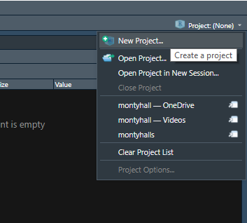

New Project

You’re going to click new directory and then start a new project with dev tools

[figure not shown]

New Directory

Once started you can edit the description in R and complete with the information thats needed

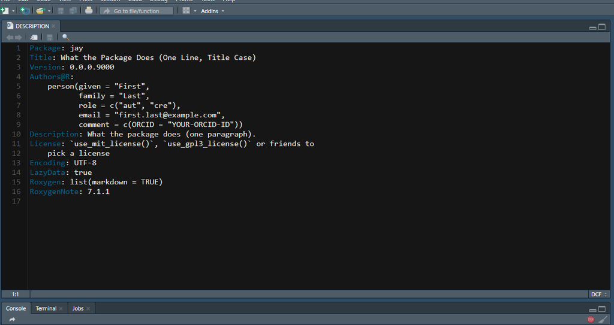

Description

# How to Add Functions

To add Functions You have to Ctrl + Shift + N. Then You will add you function and your function skeleton. To add a skeleton without copy and pasting, you can Ctrl + Alt + Shift + R. Then you want to save it as the name of the function and it will be saved under name space. Youll see the file kb memory get bigger as you add more functions.

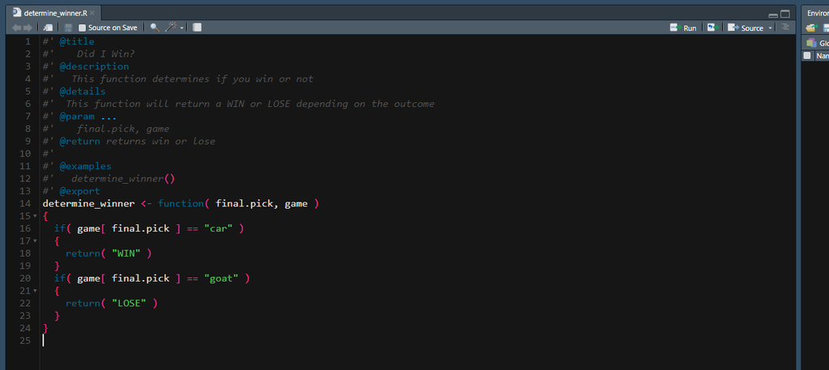

Function

To make sure the function is working properly, you want to hit check and make sure you have no errors and if you do, fix them. Then after your check is done, install and restart. You might have to do this twice to get it to work.

[figure not shown]

Double check work

# Test It

To make sure your function is working type your package name in the console and then type out the fucntion.

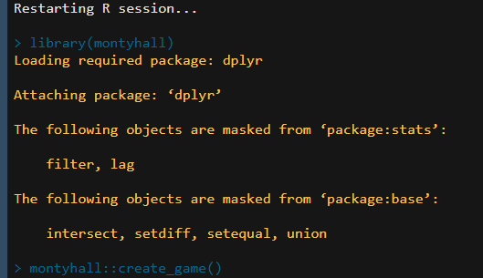

Check Function

# GitHub Hosting

You have a couple of options for sharing your new package with others. You could submit the package to the CRAN so that everyone in the world could install it in R using install.packages(“montyhall”).

We cannot use this option because (1) it’s a homework assignment so we don’t want to burden people with the task of reviewing a new package, (2) package names on the CRAN must be unique so everyone from the class would have to name it something different, and (3) the CRAN requires that the package passes some robustness checks to ensure everything is documented correctly and all of the code is running smoothly.

Now others should be able to install your package by typing:

devtools::install_github( “yourGitHubName/montyhall” )

# Warning

There might be an extra package that you might have to download a package called Rtools. website is https://cran.r-project.org/bin/windows/Rtools/ its very easy to follow along.